# **Gerdau Challenge - Team Grace Hopper**

### **c.** Projeções são importantes para avaliar situações futuras e realizar planejamentos. Faça uma projeção do consumo aparente de aço para os próximos 3 anos (2020 - 2022) e avalie quais fatores e/ou variáveis influenciam a projeção.

```python
!pip install regressors
```

```python
from sklearn.model_selection import train_test_split
import numpy as np
from regressors import stats
from sklearn.metrics import mean_absolute_error
from sklearn.metrics import mean_squared_error
from yellowbrick.regressor import ResidualsPlot
import matplotlib.pyplot as plt
from sklearn.feature_selection import RFE
from sklearn import  linear_model
```

```python
data_clear.dropna(inplace=True)
```

```python
year_data = data_clear.groupby("Ano", as_index=False).sum()
year_data.drop("Mes", axis=1, inplace=True)
year_data
```

|  | Ano | Prod Aco Bruto | Prod Laminados | Prod Laminados Planos | Prod Laminados Longos | Semiacabados P/ Venda | Semiacabados Placas | Semiacabados Blocos e Tarugos | Ferro Gusa | Vendas Internas | ... | Exportações Total US$ Milhões | Importações Laminados | Importações Laminados Planos | Importações Laminados Longos | Importações Semiacabados P/ Venda | Importações Total Mil t | Importações Total US$ Milhões | Consumo Aparente | Consumo Aparente Planos | Consumo Aparente Longos |
| --- | --- | --- | --- | --- | --- | --- | --- | --- | --- | --- | --- | --- | --- | --- | --- | --- | --- | --- | --- | --- | --- |
| 0 | 2013 | 34162.457 | 26263.127 | 15013.483 | 11249.644 | 5632.825 | 4613.988 | 1018.837 | 26200.220 | 24387.288 | ... | 5567.386 | 3693.363 | 2123.854 | 1569.509 | 10.686 | 3704.049 | 4281.424 | 28017.958 | 16115.609 | 11902.349 |
| 1 | 2014 | 33897.034 | 24905.355 | 14228.727 | 10676.628 | 7002.825 | 6508.271 | 494.554 | 27016.306 | 21708.838 | ... | 6808.335 | 3963.282 | 2416.274 | 1547.008 | 14.450 | 3977.732 | 4109.057 | 25605.659 | 14520.751 | 11084.908 |
| 2 | 2015 | 33257.587 | 22671.000 | 13388.000 | 9283.000 | 9117.000 | 7982.000 | 1135.000 | 27984.620 | 18173.000 | ... | 6585.000 | 3136.000 | 1918.000 | 1218.000 | 74.000 | 3210.000 | 3110.000 | 21295.000 | 11919.000 | 9376.000 |
| 3 | 2016 | 31642.387 | 21121.000 | 12273.000 | 8848.000 | 9434.000 | 7895.000 | 1539.000 | 26344.871 | 16828.000 | ... | 5594.000 | 1634.000 | 964.000 | 670.000 | 245.000 | 1879.000 | 1683.000 | 18520.000 | 10551.000 | 7969.000 |
| 4 | 2017 | 34777.636 | 22690.000 | 13687.000 | 9003.000 | 9980.000 | 8619.000 | 1361.000 | 28571.606 | 17247.000 | ... | 8046.000 | 2243.000 | 1597.000 | 646.000 | 86.000 | 2329.000 | 2232.000 | 19523.000 | 11687.000 | 7836.000 |
| 5 | 2018 | 35406.548 | 23696.000 | 14257.000 | 9439.000 | 9917.000 | 8761.000 | 1156.000 | 28655.085 | 18920.000 | ... | 8874.000 | 2234.000 | 1573.000 | 661.000 | 173.000 | 2407.000 | 2610.000 | 21207.000 | 12729.000 | 8478.000 |
| 6 | 2019 | 32568.934 | 22487.483 | 13245.758 | 9241.725 | 8817.209 | 7729.635 | 1087.574 | 26280.336 | 18798.943 | ... | 7307.965 | 2153.773 | 1432.441 | 721.332 | 211.374 | 2365.147 | 2462.967 | 20976.555 | 12369.295 | 8607.260 |
| 7 | 2020 | 31414.856 | 21807.280 | 12355.651 | 9451.629 | 7849.853 | 7299.731 | 550.122 | 24628.284 | 19461.985 | ... | 5270.964 | 1957.745 | 1328.453 | 629.292 | 79.593 | 2037.338 | 2171.869 | 21448.829 | 12292.495 | 9156.334 |
| 8 | 2021 | 36174.281 | 26110.830 | 15358.353 | 10752.477 | 8660.939 | 7970.321 | 690.618 | 28529.762 | 22447.596 | ... | 9345.149 | 4025.175 | 2501.619 | 1523.556 | 949.132 | 4974.307 | 4990.864 | 26481.855 | 15262.691 | 11219.164 |
| 9 | 2022 | 8502.844 | 5947.454 | 3438.104 | 2509.350 | 2089.910 | 1851.037 | 238.873 | 6515.117 | 4765.568 | ... | 2802.234 | 813.674 | 544.764 | 268.910 | 23.089 | 836.763 | 1170.927 | 5593.950 | 3253.289 | 2340.661 |

10 rows × 37 columns

```python
from sklearn.preprocessing import MinMaxScaler
scaler = MinMaxScaler()
# transform data
X = year_data.drop("Consumo Aparente", axis=1)
columns = X.columns
X = scaler.fit_transform(X)
X = pd.DataFrame(X)
X.columns = columns
print(X)
y = year_data["Consumo Aparente"]
X_train, X_test, y_train, y_test = train_test_split(X, y, test_size=0.2, random_state=42)
```

```
        Ano  Prod Aco Bruto  Prod Laminados  Prod Laminados Planos  \
0  0.000000        0.927296        1.000000               0.971069
1  0.111111        0.917704        0.933166               0.905235
2  0.222222        0.894595        0.823184               0.834705
3  0.333333        0.836225        0.746889               0.741167
4  0.444444        0.949528        0.824120               0.859789
5  0.555556        0.972255        0.873638               0.907607
6  0.666667        0.869709        0.814151               0.822773
7  0.777778        0.828002        0.780669               0.748101
8  0.888889        1.000000        0.992503               1.000000
9  1.000000        0.000000        0.000000               0.000000

   Prod Laminados Longos  Semiacabados P/ Venda  Semiacabados Placas  \
0               1.000000               0.449034             0.399850
1               0.934440               0.622669             0.673988
```

[output cut: 82 more lines]

```python
model = linear_model.LinearRegression()
rfe = RFE(estimator=model, n_features_to_select=10, step=1)
rfe.fit(X_train, y_train)
X_train.columns[rfe.support_]
```

[output not shown]

```python
X_2 = X[['Prod Aco Bruto', 'Prod Laminados', 'Prod Laminados Planos',
       'Prod Laminados Longos', 'Vendas Internas', 'Vendas Internas Laminados',
       'Vendas Externas Laminados Planos', 'Importações Laminados Longos',
       'Consumo Aparente Planos', 'Consumo Aparente Longos']]
X_2
```

|  | Prod Aco Bruto | Prod Laminados | Prod Laminados Planos | Prod Laminados Longos | Vendas Internas | Vendas Internas Laminados | Vendas Externas Laminados Planos | Importações Laminados Longos | Consumo Aparente Planos | Consumo Aparente Longos |
| --- | --- | --- | --- | --- | --- | --- | --- | --- | --- | --- |
| 0 | 0.927296 | 1.000000 | 0.971069 | 1.000000 | 1.000000 | 1.000000 | 0.290462 | 1.000000 | 1.000000 | 1.000000 |
| 1 | 0.917704 | 0.933166 | 0.905235 | 0.934440 | 0.863496 | 0.870134 | 0.499952 | 0.982700 | 0.876005 | 0.914509 |
| 2 | 0.894595 | 0.823184 | 0.834705 | 0.774991 | 0.683295 | 0.689531 | 1.000000 | 0.729733 | 0.673728 | 0.735784 |
| 3 | 0.836225 | 0.746889 | 0.741167 | 0.725222 | 0.614749 | 0.613792 | 0.810267 | 0.308389 | 0.567371 | 0.588634 |
| 4 | 0.949528 | 0.824120 | 0.859789 | 0.742956 | 0.636103 | 0.637834 | 0.921594 | 0.289936 | 0.655691 | 0.574725 |
| 5 | 0.972255 | 0.873638 | 0.907607 | 0.792839 | 0.721366 | 0.721796 | 0.701174 | 0.301469 | 0.736703 | 0.641868 |
| 6 | 0.869709 | 0.814151 | 0.822773 | 0.770269 | 0.715196 | 0.722968 | 0.502288 | 0.347857 | 0.708737 | 0.655386 |
| 7 | 0.828002 | 0.780669 | 0.748101 | 0.794284 | 0.748987 | 0.756378 | 0.283650 | 0.277089 | 0.702766 | 0.712811 |
| 8 | 1.000000 | 0.992503 | 1.000000 | 0.943118 | 0.901146 | 0.911752 | 0.341075 | 0.964668 | 0.933689 | 0.928550 |
| 9 | 0.000000 | 0.000000 | 0.000000 | 0.000000 | 0.000000 | 0.000000 | 0.000000 | 0.000000 | 0.000000 | 0.000000 |

```python
y_2 = np.log(year_data['Consumo Aparente'])
y_2
```

```
0    10.240601
1    10.150569
2     9.966228
3     9.826607
4     9.879349
5     9.962087
6     9.951161
7     9.973425
8    10.184215
9     8.629441
Name: Consumo Aparente, dtype: float64
```

```python
X_train_2, X_test_2, y_train_2, y_test_2 = train_test_split(X_2, y_2, test_size=0.3, random_state=42)
```

```python
model = linear_model.LinearRegression()
model.fit(X_train_2, y_train_2)
```

```
LinearRegression()
```

```python
xlabels = X_2.columns
stats.summary(model, X_2, y_2, xlabels)
```

```
Residuals:
    Min  1Q  Median  3Q    Max
-0.0422 0.0     0.0 0.0 0.0992


Coefficients:
                                  Estimate                  Std. Error           t value   p value
_intercept                        8.629441  3.388000e-02+0.000000e+00j  254.7084-0.0000j  0.000000
Prod Aco Bruto                    0.496687  4.188262e+00-0.000000e+00j  0.11860+0.00000j  0.908205
Prod Laminados                    0.331431  1.361068e+00+1.213559e+06j  0.00000-0.00000j  1.000000
Prod Laminados Planos             1.306547  2.761480e+00+4.178005e+05j  0.00000-0.00000j  0.999998
Prod Laminados Longos            -1.011536  9.946120e-01+2.246210e+05j -0.00000+0.00000j  0.999997
Vendas Internas                  -0.097605  5.778050e+00+0.000000e+00j -0.01690+0.00000j  0.986891
Vendas Internas Laminados         1.290994  6.773440e+00+0.000000e+00j  0.19060-0.00000j  0.853072
Vendas Externas Laminados Planos -0.199201  7.527500e-02+0.000000e+00j -2.64630+0.00000j  0.026638
Importações Laminados Longos     -0.101375  3.951690e-01-0.000000e+00j -0.25650-0.00000j  0.803304
Consumo Aparente Planos          -1.774363  1.272447e+00+0.000000e+00j -1.39440+0.00000j  0.196643
Consumo Aparente Longos           1.302152  4.358230e+00-0.000000e+00j  0.29880+0.00000j  0.771892
---
R-squared:  0.99285,    Adjusted R-squared:  1.06432
F-statistic: -13.89 on 10 features
```

```python
y_pred_2 = model.predict(X_test_2)
residuo = (y_test_2 - y_pred_2)
residuo
```

```
8   -0.099193
1    0.042202
5   -0.043476
Name: Consumo Aparente, dtype: float64
```

```python
X_test_2
```

|  | Prod Aco Bruto | Prod Laminados | Prod Laminados Planos | Prod Laminados Longos | Vendas Internas | Vendas Internas Laminados | Vendas Externas Laminados Planos | Importações Laminados Longos | Consumo Aparente Planos | Consumo Aparente Longos |
| --- | --- | --- | --- | --- | --- | --- | --- | --- | --- | --- |
| 8 | 1.000000 | 0.992503 | 1.000000 | 0.943118 | 0.901146 | 0.911752 | 0.341075 | 0.964668 | 0.933689 | 0.928550 |
| 1 | 0.917704 | 0.933166 | 0.905235 | 0.934440 | 0.863496 | 0.870134 | 0.499952 | 0.982700 | 0.876005 | 0.914509 |
| 5 | 0.972255 | 0.873638 | 0.907607 | 0.792839 | 0.721366 | 0.721796 | 0.701174 | 0.301469 | 0.736703 | 0.641868 |

```python
print("MAE", mean_absolute_error(y_test_2, y_pred_2))
print("MSE", mean_squared_error(y_test_2, y_pred_2))
print("RMSE", np.sqrt(mean_squared_error(y_test_2, y_pred_2)))
```

```
MAE 0.061623603277147034
MSE 0.004503451606405946
RMSE 0.06710776114881159
```

```python
!pip install fbprophet
```

[output not shown]

```python
!pip install prophet
```

[output not shown]

```python
from prophet import Prophet
```

```python
time = ['2013-12-31', '2014-12-31','2015-12-31', '2016-12-31','2017-12-31','2018-12-31','2019-12-31','2020-12-31','2021-12-31']
```

```python
time_series = pd.DataFrame()
time_series['ds'] = time
time_series['ds'] = pd.to_datetime(time_series['ds'])
time_series['y'] = year_data['Consumo Aparente'].copy()
time_series
```

|  | ds | y |
| --- | --- | --- |
| 0 | 2013-12-31 | 28017.958 |
| 1 | 2014-12-31 | 25605.659 |
| 2 | 2015-12-31 | 21295.000 |
| 3 | 2016-12-31 | 18520.000 |
| 4 | 2017-12-31 | 19523.000 |
| 5 | 2018-12-31 | 21207.000 |
| 6 | 2019-12-31 | 20976.555 |
| 7 | 2020-12-31 | 21448.829 |
| 8 | 2021-12-31 | 26481.855 |

```python
model = Prophet()
# fit the model
model.fit(time_series)
```

```
INFO:prophet:Disabling weekly seasonality. Run prophet with weekly_seasonality=True to override this.
INFO:prophet:Disabling daily seasonality. Run prophet with daily_seasonality=True to override this.
INFO:prophet:n_changepoints greater than number of observations. Using 6.
```

```
<prophet.forecaster.Prophet at 0x7ff3d0dfc410>
```

```python
future = model.make_future_dataframe(periods=3, freq='Y')
future.tail()
```

|  | ds |
| --- | --- |
| 7 | 2020-12-31 |
| 8 | 2021-12-31 |
| 9 | 2022-12-31 |
| 10 | 2023-12-31 |
| 11 | 2024-12-31 |

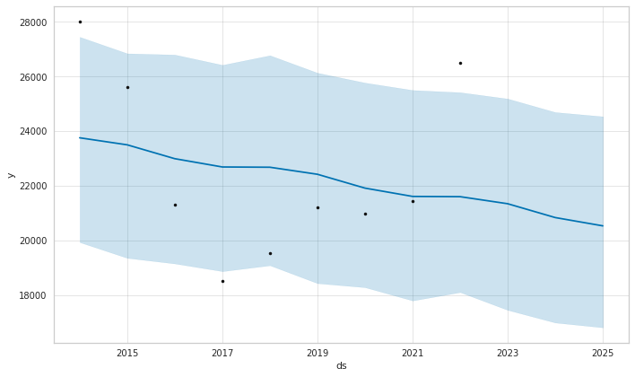

```python
prediction = model.predict(future)
fig = model.plot(prediction)
```

```python
prediction[['ds', 'yearly', 'trend']].copy().tail()
```

|  | ds | yearly | trend |
| --- | --- | --- | --- |
| 7 | 2020-12-31 | 33759.735194 | -12153.989575 |
| 8 | 2021-12-31 | 34019.911422 | -12423.356175 |
| 9 | 2022-12-31 | 34031.343860 | -12692.722774 |
| 10 | 2023-12-31 | 33794.033679 | -12962.089374 |
| 11 | 2024-12-31 | 33759.735194 | -13232.193965 |

## 2) Conhecimento Geral

Baseado nos dados (carteira_demanda.xls) fornecidos da carteira da GSP do dia 25 de março, construa os seguintes gráficos com as bibliotecas da sua preferência (seaborn, matplotlib, Altair, etc). Tente se aproximar o máximo possível a descrição fornecida na imagem

#### Carteira por tipo de demanda

A GSP atende as seguintes demanda:

- Comercial Gerdau
- Corte e Dobra
- Produção para Estoque
- Mercado Externo
- Mercado Interno
- Planta/Transferência

Precisamos criar um gráfico que mostre os volumes da nossa carteira para cada mês e para cada tipo de demanda, além de ter a visão se a carteira foi predita ou ela já está implantada.

Faça uma breve descrição do gráfico e explique os filtros/tratamento nos dados

#### **Importação e formatação dos dados**

```python
# leitura do arquivo excel para responder a questão
carteira = pd.read_excel("carteira_demanda.xls")
carteira
```

|  | abc_curve | client_id | client_name | confirmed_date | demand_type | document_id | document_item | due_month | fevor | make_to | ... | plant_id | postponed_date | predicted | product_type | promised_date | quantity_old | quantity | sales_organization | material_aggregation | component_material_type |
| --- | --- | --- | --- | --- | --- | --- | --- | --- | --- | --- | --- | --- | --- | --- | --- | --- | --- | --- | --- | --- | --- |
| 0 | NaN | 4416 | 4416 | 2021-03-24 | Comercial Gerdau | 4513942120 | 10 | M0 | 251 | MTS | ... | 1407 | NaT | False | ACABADO | 2021-05-28 | 1232000.0 | 1232.000 | BRTR | RETO_10MM_INTERNAL_LCT_160 | TARUGO_LCT_160 |
| 1 | NaN | 4416 | 4416 | 2021-03-24 | Comercial Gerdau | 4514028107 | 10 | M0 | 251 | MTS | ... | 1407 | NaT | False | ACABADO | 2021-06-26 | 524000.0 | 524.000 | BRTR | RETO_6,3MM_INTERNAL_LCT_160 | TARUGO_LCT_160 |
| 2 | NaN | 4416 | 4416 | 2021-03-23 | Comercial Gerdau | 4514085943 | 10 | M0 | 251 | MTS | ... | 1407 | NaT | False | ACABADO | 2021-04-02 | 300000.0 | 300.000 | BRTR | RETO_12,5MM_INTERNAL_LCT_160 | TARUGO_LCT_160 |
| 3 | NaN | 100199230 | EMPRESA CONCESSIONARIA DE RODOVI | 2021-01-25 | Mercado Interno | 10164961 | 30 | M0 | 251 | MTS | ... | 1407 | NaT | False | ACABADO | 2021-05-14 | 228957.0 | 228.957 | BRCC | RETO_20MM_INTERNAL_LCT_160 | TARUGO_LCT_160 |
| 4 | NaN | 100240094 | GERDAU LAISA S A | 2021-03-31 | Mercado Externo | 10337836 | 1 | M0 | 251 | MTO | ... | 1407 | NaT | False | ACABADO | 2021-05-15 | 199936.0 | 199.936 | BREX | CARRETEL_12,5MM_EXPORT_LCT_160 | TARUGO_LCT_160 |
| ... | ... | ... | ... | ... | ... | ... | ... | ... | ... | ... | ... | ... | ... | ... | ... | ... | ... | ... | ... | ... | ... |
| 11825 | NaN | 100202740 | PRE FABRICAR CONSTRUCOES LTDA | 2021-12-10 | Mercado Interno | 9507847 | 80 | M9 | 251 | MTS | ... | 1407 | 2021-12-10 | False | ACABADO | 2021-12-10 | 25000.0 | 25.000 | BRCC | CARRETEL_20MM_INTERNAL_LCT_160 | TARUGO_LCT_160 |
| 11826 | A | 100202740 | PRE FABRICAR CONSTRUCOES LTDA | 2021-12-10 | Mercado Interno | 9507847 | 70 | M9 | 251 | MTS | ... | 1407 | 2021-12-10 | False | ACABADO | 2021-12-10 | 25000.0 | 25.000 | BRCC | CARRETEL_20MM_INTERNAL_LCT_160 | TARUGO_LCT_160 |
| 11827 | NaN | 100202740 | PRE FABRICAR CONSTRUCOES LTDA | 2021-12-10 | Mercado Interno | 9507847 | 40 | M9 | 251 | MTS | ... | 1407 | 2021-12-10 | False | ACABADO | 2021-12-10 | 21875.0 | 21.875 | BRCC | CARRETEL_10MM_INTERNAL_LCT_160 | TARUGO_LCT_160 |
| 11828 | NaN | 100202740 | PRE FABRICAR CONSTRUCOES LTDA | 2021-12-10 | Mercado Interno | 9507847 | 10 | M9 | 251 | MTS | ... | 1407 | 2021-12-10 | False | ACABADO | 2021-12-10 | 20448.0 | 20.448 | BRCC | CARRETEL_6,3MM_INTERNAL_LCT_160 | TARUGO_LCT_160 |
| 11829 | NaN | 100955788 | RIO PRETO INDUSTRIA E COMERCIO | 2021-12-31 | Mercado Interno | 10175906 | 10 | M9 | 251 | MTS | ... | 1407 | NaT | False | ACABADO | 2021-12-31 | 20000.0 | 20.000 | BRDI | RETO_10MM_INTERNAL_LCT_160 | TARUGO_LCT_160 |

11830 rows × 27 columns

```python
# informações das variáveis
carteira.info()
```

```
<class 'pandas.core.frame.DataFrame'>
RangeIndex: 11830 entries, 0 to 11829
Data columns (total 27 columns):
 #   Column                   Non-Null Count  Dtype
---  ------                   --------------  -----
 0   abc_curve                6034 non-null   object
 1   client_id                11830 non-null  int64
 2   client_name              11830 non-null  object
 3   confirmed_date           11830 non-null  datetime64[ns]
 4   demand_type              11830 non-null  object
 5   document_id              11830 non-null  int64
 6   document_item            11830 non-null  int64
 7   due_month                11830 non-null  object
 8   fevor                    11830 non-null  int64
 9   make_to                  11830 non-null  object
```

[output cut: 19 more lines]

```python
# agrupamente das variáveis que serão necessárias para a análise encontrar a soma da coluna quantity
grafico = carteira.groupby(['predicted','due_month','demand_type']).agg({'quantity': 'sum'}).reset_index()
grafico
```

|  | predicted | due_month | demand_type | quantity |
| --- | --- | --- | --- | --- |
| 0 | False | M0 | Comercial Gerdau | 7200.091000 |
| 1 | False | M0 | Corte e Dobra | 10153.431000 |
| 2 | False | M0 | Mercado Externo | 1333.928700 |
| 3 | False | M0 | Mercado Interno | 51133.133690 |
| 4 | False | M0 | Planta | 120.455000 |
| 5 | False | M1 | Comercial Gerdau | 1207.819000 |
| 6 | False | M1 | Corte e Dobra | 8940.197000 |
| 7 | False | M1 | Mercado Externo | 399.936000 |
| 8 | False | M1 | Mercado Interno | 19338.555000 |
| 9 | False | M1 | Planta | 300.000000 |
| 10 | False | M2 | Comercial Gerdau | 972.996000 |
| 11 | False | M2 | Corte e Dobra | 4091.464000 |
| 12 | False | M2 | Mercado Interno | 9483.137000 |
| 13 | False | M3 | Corte e Dobra | 231.226000 |
| 14 | False | M3 | Mercado Interno | 3255.431000 |
| 15 | False | M4 | Comercial Gerdau | 6.000000 |
| 16 | False | M4 | Mercado Interno | 1313.987000 |
| 17 | False | M5 | Mercado Interno | 310.667000 |
| 18 | False | M6 | Mercado Interno | 212.823000 |
| 19 | False | M7 | Mercado Interno | 217.323000 |
| 20 | False | M8 | Mercado Interno | 215.879000 |
| 21 | False | M9 | Mercado Interno | 237.323000 |
| 22 | True | M1 | Comercial Gerdau | 376.484326 |
| 23 | True | M1 | Estoque | 5748.151114 |
| 24 | True | M2 | Comercial Gerdau | 442.114310 |
| 25 | True | M2 | Mercado Interno | 7730.913180 |
| 26 | True | M3 | Comercial Gerdau | 552.429777 |
| 27 | True | M3 | Mercado Interno | 10801.729199 |
| 28 | True | M4 | Comercial Gerdau | 498.592531 |
| 29 | True | M4 | Mercado Interno | 11455.453627 |
| 30 | True | M5 | Comercial Gerdau | 509.874086 |
| 31 | True | M5 | Mercado Interno | 11039.026232 |

```python
# informações da variável
grafico.info()
```

```
<class 'pandas.core.frame.DataFrame'>
RangeIndex: 32 entries, 0 to 31
Data columns (total 4 columns):
 #   Column       Non-Null Count  Dtype
---  ------       --------------  -----
 0   predicted    32 non-null     bool
 1   due_month    32 non-null     object
 2   demand_type  32 non-null     object
 3   quantity     32 non-null     float64
dtypes: bool(1), float64(1), object(2)
memory usage: 928.0+ bytes
```

#### **Descrição do gráfico e explicação dos filtros**

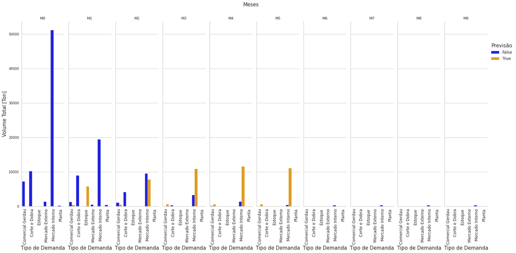

```python
# utilização de gráfico catplot pela facilidade de dividir em colunas e categorias da legenda e, possibilidade de ornenar o eixo x, para aproximar-se a imagem exemplo da questão
sns.set_style("whitegrid") # fundo quadriculado do gráfico
g = sns.catplot(x="demand_type", # eixo x
                y="quantity", #  eixo y
                col="due_month", # divisão em coluna o eixo x
                hue="predicted", # divisão da carteira em predita ou implantada (True/False).
                data=grafico, # base de dados
                kind="bar", # estilo do gráfico
                palette=["blue","orange"], # cor das barras
                legend=False, # remove legenda automática
                order = ["Comercial Gerdau", "Corte e Dobra", "Estoque","Mercado Externo", "Mercado Interno", "Planta"]) # ordem dos tipos do eixo x interno
g.fig.subplots_adjust(top=0.9) # distância do topo
g.fig.suptitle('Meses',fontsize=15) #título do gráfico e tamanho da letra
g.set_axis_labels("Tipo de Demanda", "Volume Total [Ton]", fontsize=15) # título dos eixos e tamanho a letra
g.set_titles("{col_name}") # título das colunas, seleciona o nome que está na determinada linha
g.set_xlabels(fontsize=15) # tamanho da label do eixo x externo
g.set_xticklabels(fontsize=12) # tamanho da label do eixo x interno
g.set_ylabels(fontsize=15) # tamanho dos númeris do eixo y
g.figure.set_size_inches(20,10) # tamanho da figura
plt.legend(title = "Previsão", title_fontsize = 15,bbox_to_anchor = (1,0.9), loc=2, fontsize=12) # inserindo a legenda e sua posição
for ax in g.axes.flat: # condição para rotacionar a 90º as labels internas do eixo x
    for label in ax.get_xticklabels():
        label.set_rotation(90)
```

```python
# conclusão
print("No gráfico é possível observar que no mês M0 todas as demandas foram implantadas e no decorrer dos meses esse valor vai decrescendo, no mês M1 as demandas preditas aparecem mais em Estoque, e nos meses seguintes passam para o Mercado Interno. A partir do M6 as demandas estão com valores quase zerados.")
```

[output not shown]